# EDA Project

The EDA project in this course has four main parts to it:  
1. Project Proposal 2. Phase 1 3. Phase 2 4. Report This notebook will be used for Project Proposal, Phase 1, and Phase 2. You will have specific questions to answer within this notebook for Project Proposal and Phase 1. You will also continue using this notebook for Phase 2. However, guidance and expectations can be found on Canvas for that assignment. The report is completed outside of this notebook (delivered as a PDF). Detailed instructions for that assignment are provided in Canvas.

**Read this before proceeding:** 1. Review the list of data sets and sources of data to avoid before choosing your data. This list is provided in the instructions for the Project Proposal assignment in Canvas.  
2. It is expected that when you are asked questions requiring typed explanations you are to use a **markdown cell** to type your answers neatly. *Do not provide typed answers to questions as extra comments within your code.* Only provide comments within your code as you normally would, i.e. as needed to explain or remind yourself what each part of the code is doing.

# Project Proposal

The intent of this assignment is for you to share your chosen data file(s) with your instructor and provide general information on your goals for the EDA project.

**Step 1 (2 pts)**: Give a brief *description* of the source(s) of your data and include a *direct link* to your data.

We took data from Open Chicago which is a open data portal for chicago. Link: https://data.cityofchicago.org/Transportation/Traffic-Crashes-Crashes-Dashboard/8tdq-a5dp Its a report of all traffic related crashes we will ONLY be taking data from Feb-Apr of 2020 and 2019.

**Step 2 (2 pts)**: Briefly explain why you chose this data.

We chose this data because we want to see the affects of covid and the stay at home mandate had on traffic crashes. The data included information such as, cause of crash, speed limit, if it was in an intersection and time of the accident. The data included things like speed limit, intersection type, hit and run, etc etc.

**Step 3 (1 pt)**: Provide a brief overview of your goals for this project.

We want to see how covid and the stay at home mandate has affected how people drove and to see if there was more or less incidents and the severity of the accident. An example would be if there was increase in intersection crashes we could determine if people ran more red lights and or was speeding and we would compare the data from 2020 to 2019 and see what changed.

**Step 4 (1 pt)**: Read the data into this notebook.

```python
import pandas as pd
crashes19 = pd.read_csv("Crashes_Feb-Apr_2019-2.csv")
crashes20 = pd.read_csv("Crashes_Feb-Apr_2020-2.csv")
```

**Step 5 (1 pt)**: Inspect the data using the **info( )**, **head( )**, and **tail( )** methods.

```python
# TODO: Use the info() method to determine to inspect the variable (column) names, the number of non-null values,
#       and the data types for each variable.
crashes19.info()
crashes20.info()

# TODO: Use the head() method to inspect the first five (or more) rows of the data
crashes19.head(5)
crashes20.head(5)


# TODO: Use the tail() method to inspect the last five (or more) rows of the data
crashes19.tail(5)
crashes20.tail(5)
```

```
<class 'pandas.core.frame.DataFrame'>
RangeIndex: 27817 entries, 0 to 27816
Data columns (total 49 columns):
 #   Column                         Non-Null Count  Dtype
---  ------                         --------------  -----
 0   CRASH_RECORD_ID                27817 non-null  object
 1   RD_NO                          27817 non-null  object
 2   CRASH_DATE_EST_I               2113 non-null   object
 3   CRASH_DATE                     27817 non-null  object
 4   POSTED_SPEED_LIMIT             27817 non-null  int64
 5   TRAFFIC_CONTROL_DEVICE         27817 non-null  object
 6   DEVICE_CONDITION               27817 non-null  object
 7   WEATHER_CONDITION              27817 non-null  object
 8   LIGHTING_CONDITION             27817 non-null  object
 9   FIRST_CRASH_TYPE               27817 non-null  object
```

[output cut: 97 more lines]

|  | CRASH_RECORD_ID | RD_NO | CRASH_DATE_EST_I | CRASH_DATE | POSTED_SPEED_LIMIT | TRAFFIC_CONTROL_DEVICE | DEVICE_CONDITION | WEATHER_CONDITION | LIGHTING_CONDITION | FIRST_CRASH_TYPE | ... | INJURIES_NON_INCAPACITATING | INJURIES_REPORTED_NOT_EVIDENT | INJURIES_NO_INDICATION | INJURIES_UNKNOWN | CRASH_HOUR | CRASH_DAY_OF_WEEK | CRASH_MONTH | LATITUDE | LONGITUDE | LOCATION |
| --- | --- | --- | --- | --- | --- | --- | --- | --- | --- | --- | --- | --- | --- | --- | --- | --- | --- | --- | --- | --- | --- |
| 20112 | 8f34f09bed24367843593363cd2538de5ac5dfd21cf84a... | JD221008 | NaN | 04/30/2020 09:28:00 PM | 30 | TRAFFIC SIGNAL | FUNCTIONING PROPERLY | CLEAR | DARKNESS | REAR END | ... | 0.0 | 0.0 | 2.0 | 0.0 | 21 | 5 | 4 | 41.852622 | -87.719883 | POINT (-87.719882943839 41.852622144108) |
| 20113 | 52aa28ac605d5df26ccf9aea3605d20f7801f931fb1cd2... | JD221020 | NaN | 04/30/2020 09:45:00 PM | 25 | NO CONTROLS | NO CONTROLS | CLEAR | DARKNESS, LIGHTED ROAD | HEAD ON | ... | 0.0 | 0.0 | 2.0 | 0.0 | 21 | 5 | 4 | 41.913491 | -87.712443 | POINT (-87.712443302949 41.913491429873) |
| 20114 | c28fb8a5c50a79b0cd87988abb0dd06b60a0a23ebadf5f... | JD221028 | NaN | 04/30/2020 09:45:00 PM | 30 | STOP SIGN/FLASHER | FUNCTIONING PROPERLY | CLEAR | DARKNESS, LIGHTED ROAD | ANGLE | ... | 0.0 | 2.0 | 1.0 | 0.0 | 21 | 5 | 4 | 41.781333 | -87.654693 | POINT (-87.654693165212 41.781333347606) |
| 20115 | b592bd3ca192e8e0a19e5f6f1189b9688aa79b343af3f9... | JD221056 | NaN | 04/30/2020 11:00:00 PM | 30 | NO CONTROLS | NO CONTROLS | CLEAR | DARKNESS, LIGHTED ROAD | PARKED MOTOR VEHICLE | ... | 0.0 | 0.0 | 2.0 | 0.0 | 23 | 5 | 4 | 41.869261 | -87.704275 | POINT (-87.704275111021 41.869261255539) |
| 20116 | 5fbe08f097aa961a4ec1cfa3f5a934087d0a8ea2f3c795... | JD221079 | N | 04/30/2020 11:40:00 PM | 25 | NO CONTROLS | NO CONTROLS | CLEAR | DARKNESS, LIGHTED ROAD | PARKED MOTOR VEHICLE | ... | 0.0 | 0.0 | 1.0 | 0.0 | 23 | 5 | 4 | 41.715683 | -87.655081 | POINT (-87.655080745516 41.715682721723) |

5 rows × 49 columns

**STOP HERE for your Project Proposal assignment. Submit your (1) original data file(s) along with (2) the completed notebook up to this point, and (3) the html file for grading and approval.**

**Instructor Feedback and Approval (3 pts)**: Your instructor will provide feedback in either the cell below this or via Canvas. You can expect one of the following point values for this portion. **3 pts** - if your project goals and data set are both approved.  
**2 pts** - if your data set is approved but changes to your project goals (Step 3) are needed.  
**1 pt** - if your project goals are approved but your data set is not approved.  
**0 pts** - if neither your data set nor your project goals are approved.  
*As needed, follow your instructor's feeback and guidance to get on track for the remaining portions of the EDA project.*

# EDA Phase 1

The overall goal of this assignment is to take all necessary steps to inspect the quality of your data and prepare the data according to your needs. For information and resources on the process of Exploratory Data Analysis (EDA), you should explore the **EDA Project Resources Module** in Canvas. Once you’ve read through the information provided in that module and have a comfortable understanding of EDA using Python, complete steps 6 through 10 listed below to satisfy the requirements for your EDA Phase 1 assignment. **Remember to convert code cells provided to markdown cells for any typed responses to questions.**

**Step 6 (2 pts)**: Begin by elaborating in more detail from the previous assignment on why you chose this data?  
1. Explain what you hope to learn from this data. 2. Do you have a hunch about what this data will reveal? (The answer to this question will be used in the Introduction section of your EDA report.)

1. We want to find out how much of an impact Stay at Home order would have on the overall crash situation in Chicago and whether the causes of crashes would have changed.
2. There will naturally be a significant drop in the overall number of crashes, but data on night-time driving and speeding is likely to focus on the report. There are also implications for changes in the boundaries of accidents and the proportion of accidents that escape.

**Step 7 (2 pts)**: Discuss the popluation and the sample:  
1. What is the population being represented by the data you’ve chosen? 2. What is the total sample size?

**Step 8 (2 pts)**: Describe how the data was collected. For example, is this a random sample? Are sampling weights used with the data?

Some accidents are reported voluntarily and recorded in a database, while others are recorded at the scene by a police officer.

**Step 9 (4 pts)**: In the Project Proposal assignment you used the info( ) method to inspect the variables, their data types, and the number of non-null values. Using that information as a guide, provide definitions of each of your variables and their corresponding data types, i.e. a data dictionary. Also indicate which variables will be used for your purposes.

Below I will list all the column names in the data source with the desription. For the columns that we're going to use in the project, I will bold them.

1. **CRASH_RECORD_ID**: This number can be used to link to the same crash in the Vehicles and People datasets. This number also serves as a unique ID in this dataset.
2. RD_NO: Chicago Police Department report number. For privacy reasons, this column is blank for recent crashes.
3. CRASH_DATE_EST_I: Crash date estimated by desk officer or reporting party
4. **CRASH_DATE**: Date and time of crash as entered by the reporting officer
5. **POSTED_SPEED_LIMIT**: Posted speed limit, as determined by reporting officer
6. TRAFFIC_CONTROL_DEVICE: Traffic control device present at crash location, as determined by reporting officer
7. **DEVICE_CONDITION**: Condition of traffic control device, as determined by reporting officer
8. **WEATHER_CONDITION**: Weather condition at time of crash, as determined by reporting officer
9. **LIGHTING_CONDITION**: Light condition at time of crash, as determined by reporting officer
10. **FIRST_CRASH_TYPE**: Type of first collision in crash
11. **TRAFFICWAY_TYPE**: Trafficway type, as determined by reporting officer
12. LANE_CNT: Total number of through lanes in either direction, excluding turn lanes, as determined by reporting officer (0 = intersection)
13. ALIGNMENT: Street alignment at crash location, as determined by reporting officer
14. **ROADWAY_SURFACE_COND**: Road surface condition, as determined by reporting officer
15. **ROAD_DEFECT**: Road defects, as determined by reporting officer
16. REPORT_TYPE: Administrative report type (at scene, at desk, amended)
17. CRASH_TYPE: A general severity classification for the crash. Can be either Injury and/or Tow Due to Crash or No Injury / Drive Away
18. INTERSECTION_RELATED_I: A field observation by the police officer whether an intersection played a role in the crash. Does not represent whether or not the crash occurred within the intersection.
19. NOT_RIGHT_OF_WAY_I: Whether the crash begun or first contact was made outside of the public right-of-way.
20. **HIT_AND_RUN_I**: Crash did/did not involve a driver who caused the crash and fled the scene without exchanging information and/or rendering aid
21. **DAMAGE**: A field observation of estimated damage.
22. **DATE_POLICE_NOTIFIED**: Calendar date on which police were notified of the crash
23. **PRIM_CONTRIBUTORY_CAUSE**: The factor which was most significant in causing the crash, as determined by officer judgment
24. **SEC_CONTRIBUTORY_CAUSE**: The factor which was second most significant in causing the crash, as determined by officer judgment
25. STREET_NO: Street address number of crash location, as determined by reporting officer
26. STREET_DIRECTION: Street address direction (N,E,S,W) of crash location, as determined by reporting officer
27. STREET_NAME: Street address name of crash location, as determined by reporting officer
28. **BEAT_OF_OCCURRENCE**: Chicago Police Department Beat ID. Boundaries available at https://data.cityofchicago.org/d/aerh-rz74
29. PHOTOS_TAKEN_I: Whether the Chicago Police Department took photos at the location of the crash
30. STATEMENTS_TAKEN_I: Whether statements were taken from unit(s) involved in crash
31. DOORING_I: Whether crash involved a motor vehicle occupant opening a door into the travel path of a bicyclist, causing a crash
32. WORK_ZONE_I: Whether the crash occurred in an active work zone
33. WORK_ZONE_TYPE: The type of work zone, if any
34. WORKERS_PRESENT_I: Whether construction workers were present in an active work zone at crash location
35. NUM_UNITS: Number of units involved in the crash. A unit can be a motor vehicle, a pedestrian, a bicyclist, or another non-passenger roadway user. Each unit represents a mode of traffic with an independent trajectory.
36. MOST_SEVERE_INJURY: Most severe injury sustained by any person involved in the crash
37. **INJURIES_TOTAL**: Total persons sustaining fatal, incapacitating, non-incapacitating, and possible injuries as determined by the reporting officer
38. INJURIES_FATAL: Total persons sustaining fatal injuries in the crash
39. INJURIES_INCAPACITATING: Total persons sustaining incapacitating/serious injuries in the crash as determined by the reporting officer. Any injury other than fatal injury, which prevents the injured person from walking, driving, or normally continuing the activities they were capable of performing before the injury occurred. Includes severe lacerations, broken limbs, skull or chest injuries, and abdominal injuries.
40. INJURIES_NON_INCAPACITATING: Total persons sustaining non-incapacitating injuries in the crash as determined by the reporting officer. Any injury, other than fatal or incapacitating injury, which is evident to observers at the scene of the crash. Includes lump on head, abrasions, bruises, and minor lacerations.
41. INJURIES_REPORTED_NOT_EVIDENT: Total persons sustaining possible injuries in the crash as determined by the reporting officer. Includes momentary unconsciousness, claims of injuries not evident, limping, complaint of pain, nausea, and hysteria.
42. INJURIES_NO_INDICATION: Total persons sustaining no injuries in the crash as determined by the reporting officer
43. INJURIES_UNKNOWN: Total persons for whom injuries sustained, if any, are unknown
44. CRASH_HOUR: The hour of the day component of CRASH_DATE.
45. CRASH_DAY_OF_WEEK: The day of the week component of CRASH_DATE. Sunday=1
46. CRASH_MONTH: The month component of CRASH_DATE.
47. LATITUDE: The latitude of the crash location, as determined by reporting officer, as derived from the reported address of crash
48. LONGITUDE: The longitude of the crash location, as determined by reporting officer, as derived from the reported address of crash
49. LOCATION: The crash location, as determined by reporting officer, as derived from the reported address of crash, in a column type that allows for mapping and other geographic analysis in the data portal software

**Step 10 (10 pts)**: For full credit in this problem you'll want to *take all necessary steps to report on the quality of the data* and *clean the data accordingly*. Some things to consider while doing this are listed below. **Depending on your data and goals, there may be additional steps needed than those listed here.** 1. Are there rows with missing or inconsistent values? If so, eliminate those rows from your data where appropriate. 2. Are there any outliers or duplicate rows? If so, eliminate those rows from your data where appropriate. At each stage of cleaning the data, state how many rows were eliminated. 3. Are you using all columns (variables) in the data? If not, are you eliminating those columns? 4. Consider some type of visual display such as a boxplot to determine any outliers. Do any outliers need removed? If so, how many were removed? At each stage of cleaning the data, state how many rows were eliminated. *It is good practice to get the shape of the data before and after each step in cleaning the data and add typed explanations (in separate markdown cells) of the steps taken to clean the data.*

Include the rest of your work below and insert cells where needed.

```python
# https://jakevdp.github.io/blog/2017/12/05/installing-python-packages-from-jupyter/
import sys
!conda update --yes --prefix {sys.prefix} seaborn
```

[output not shown]

```python
# load up modules
import pandas as pd
import numpy as np
import re
import seaborn as sns

# set up notebook to display multiple output in one cell
from IPython.core.interactiveshell import InteractiveShell
InteractiveShell.ast_node_interactivity = "all"
```

```python
#Load the raw data from Crashes_Feb-Apr_2019.csv
crashes_2019 = pd.read_csv('Crashes_Feb-Apr_2019-2.csv')
crashes_2019.shape
#Before clean data we have 27,817 rows and 49 columns

#inspect the data
crashes_2019.info()

#Drop 32 columns what we would not use in our project
col_to_drop_2019 = ['RD_NO','CRASH_DATE_EST_I','TRAFFIC_CONTROL_DEVICE','LANE_CNT','ALIGNMENT','REPORT_TYPE','CRASH_TYPE','INTERSECTION_RELATED_I','NOT_RIGHT_OF_WAY_I','STREET_NO','STREET_DIRECTION','STREET_NAME','PHOTOS_TAKEN_I','STATEMENTS_TAKEN_I','DOORING_I','WORK_ZONE_I','WORK_ZONE_TYPE','WORKERS_PRESENT_I','NUM_UNITS','MOST_SEVERE_INJURY','INJURIES_FATAL','INJURIES_INCAPACITATING','INJURIES_NON_INCAPACITATING','INJURIES_REPORTED_NOT_EVIDENT','INJURIES_NO_INDICATION','INJURIES_UNKNOWN','CRASH_HOUR','CRASH_DAY_OF_WEEK','CRASH_MONTH','LATITUDE','LONGITUDE','LOCATION']
crashes_2019_reviews = crashes_2019.drop(columns = col_to_drop_2019, inplace=False)

#inspect the data after drop columns
crashes_2019_reviews.info()



#display the number of missing values in each column
```

```
(27817, 49)
```

```
<class 'pandas.core.frame.DataFrame'>
RangeIndex: 27817 entries, 0 to 27816
Data columns (total 49 columns):
 #   Column                         Non-Null Count  Dtype
---  ------                         --------------  -----
 0   CRASH_RECORD_ID                27817 non-null  object
 1   RD_NO                          27817 non-null  object
 2   CRASH_DATE_EST_I               2113 non-null   object
 3   CRASH_DATE                     27817 non-null  object
 4   POSTED_SPEED_LIMIT             27817 non-null  int64
 5   TRAFFIC_CONTROL_DEVICE         27817 non-null  object
 6   DEVICE_CONDITION               27817 non-null  object
 7   WEATHER_CONDITION              27817 non-null  object
 8   LIGHTING_CONDITION             27817 non-null  object
 9   FIRST_CRASH_TYPE               27817 non-null  object
```

[output cut: 65 more lines]

```python
#display the missing values in each column
crashes_2019_reviews.isnull().sum()

#HIT_AND_RUN_I is missing a lot of data, but it is just a support value in the project, so I will keep it.
#Need to clean missing data from INJURIES_TOTAL
#Find out all missing INJURIES_TOTAL
crashes_2019_reviews.INJURIES_TOTAL.isnull().sum()
missing_INJURIES_TOTAL = crashes_2019_reviews[crashes_2019_reviews.INJURIES_TOTAL.isnull()][['INJURIES_TOTAL']]
missing_INJURIES_TOTAL
#Drop missing INJURIES_TOTAL from the dataset
crashes_2019_reviews = crashes_2019_reviews.drop(missing_INJURIES_TOTAL.index)
crashes_2019_reviews.shape
#Removed 74 rows what are missing INJURIES_TOTAL
crashes_2019_reviews.info()
```

```
CRASH_RECORD_ID                0
CRASH_DATE                     0
POSTED_SPEED_LIMIT             0
DEVICE_CONDITION               0
WEATHER_CONDITION              0
LIGHTING_CONDITION             0
FIRST_CRASH_TYPE               0
TRAFFICWAY_TYPE                0
ROADWAY_SURFACE_COND           0
ROAD_DEFECT                    0
HIT_AND_RUN_I              19833
DAMAGE                         0
DATE_POLICE_NOTIFIED           0
PRIM_CONTRIBUTORY_CAUSE        0
SEC_CONTRIBUTORY_CAUSE         0
BEAT_OF_OCCURRENCE             0
INJURIES_TOTAL                74
dtype: int64
```

```
74
```

|  | INJURIES_TOTAL |
| --- | --- |
| 598 | NaN |
| 733 | NaN |
| 739 | NaN |
| 1201 | NaN |
| 1387 | NaN |
| ... | ... |
| 26663 | NaN |
| 26805 | NaN |
| 26838 | NaN |
| 27425 | NaN |
| 27465 | NaN |

74 rows × 1 columns

```
(27743, 17)
```

```
<class 'pandas.core.frame.DataFrame'>
Int64Index: 27743 entries, 0 to 27816
Data columns (total 17 columns):
 #   Column                   Non-Null Count  Dtype
---  ------                   --------------  -----
 0   CRASH_RECORD_ID          27743 non-null  object
 1   CRASH_DATE               27743 non-null  object
 2   POSTED_SPEED_LIMIT       27743 non-null  int64
 3   DEVICE_CONDITION         27743 non-null  object
 4   WEATHER_CONDITION        27743 non-null  object
 5   LIGHTING_CONDITION       27743 non-null  object
 6   FIRST_CRASH_TYPE         27743 non-null  object
 7   TRAFFICWAY_TYPE          27743 non-null  object
 8   ROADWAY_SURFACE_COND     27743 non-null  object
 9   ROAD_DEFECT              27743 non-null  object
 10  HIT_AND_RUN_I            7958 non-null   object
 11  DAMAGE                   27743 non-null  object
 12  DATE_POLICE_NOTIFIED     27743 non-null  object
 13  PRIM_CONTRIBUTORY_CAUSE  27743 non-null  object
 14  SEC_CONTRIBUTORY_CAUSE   27743 non-null  object
 15  BEAT_OF_OCCURRENCE       27743 non-null  int64
 16  INJURIES_TOTAL           27743 non-null  float64
dtypes: float64(1), int64(2), object(14)
memory usage: 3.8+ MB
```

```python
#Check duplicate cases,CRASH_RECORD_ID is unique, the count of CRASH_RECORD_ID should be equal to the rows
len(crashes_2019_reviews.CRASH_RECORD_ID.value_counts())
#No duplicated rows
```

```
27743
```

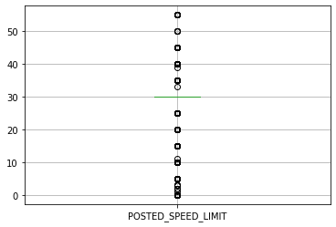

```python
#create a boxplot for POSTED_SPEED_LIMIT to review any outliers
crashes_2019_reviews.boxplot(column=['POSTED_SPEED_LIMIT'])
#There is no unexpected data, so no deletion on POSTED_SPEED_LIMIT
```

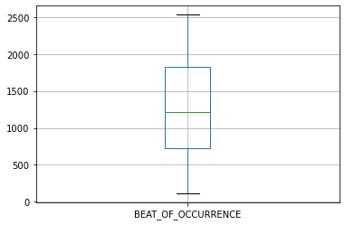

```python
#create a boxplot for BEAT_OF_OCCURRENCE to review any outliers
crashes_2019_reviews.boxplot(column=['BEAT_OF_OCCURRENCE'])
#There is no unexpected data, so no deletion on BEAT_OF_OCCURRENCE
```

```python
#Save the cleaned Crashes 2019 data to Crashes_Feb-Apr_2019_Clean.csv
crashes_2019_reviews.to_csv('Crashes_Feb-Apr_2019_Clean.csv',index=False)
```

```python
#Load the raw data from Crashes_Feb-Apr_2020.csv
crashes_2020 = pd.read_csv('Crashes_Feb-Apr_2020-2.csv')
crashes_2020.shape
#Before clean data we have 20,117 rows and 49 columns

#inspect the data
crashes_2020.info()

#Drop 32 columns what we would not use in our project
col_to_drop_2020 = ['RD_NO','CRASH_DATE_EST_I','TRAFFIC_CONTROL_DEVICE','LANE_CNT','ALIGNMENT','REPORT_TYPE','CRASH_TYPE','INTERSECTION_RELATED_I','NOT_RIGHT_OF_WAY_I','STREET_NO','STREET_DIRECTION','STREET_NAME','PHOTOS_TAKEN_I','STATEMENTS_TAKEN_I','DOORING_I','WORK_ZONE_I','WORK_ZONE_TYPE','WORKERS_PRESENT_I','NUM_UNITS','MOST_SEVERE_INJURY','INJURIES_FATAL','INJURIES_INCAPACITATING','INJURIES_NON_INCAPACITATING','INJURIES_REPORTED_NOT_EVIDENT','INJURIES_NO_INDICATION','INJURIES_UNKNOWN','CRASH_HOUR','CRASH_DAY_OF_WEEK','CRASH_MONTH','LATITUDE','LONGITUDE','LOCATION']
crashes_2020_reviews = crashes_2020.drop(columns = col_to_drop_2020, inplace=False)

#inspect the data after drop columns
crashes_2020_reviews.info()

#display the number of missing values in each column
```

```
(20117, 49)
```

```
<class 'pandas.core.frame.DataFrame'>
RangeIndex: 20117 entries, 0 to 20116
Data columns (total 49 columns):
 #   Column                         Non-Null Count  Dtype
---  ------                         --------------  -----
 0   CRASH_RECORD_ID                20117 non-null  object
 1   RD_NO                          20117 non-null  object
 2   CRASH_DATE_EST_I               1447 non-null   object
 3   CRASH_DATE                     20117 non-null  object
 4   POSTED_SPEED_LIMIT             20117 non-null  int64
 5   TRAFFIC_CONTROL_DEVICE         20117 non-null  object
 6   DEVICE_CONDITION               20117 non-null  object
 7   WEATHER_CONDITION              20117 non-null  object
 8   LIGHTING_CONDITION             20117 non-null  object
 9   FIRST_CRASH_TYPE               20117 non-null  object
```

[output cut: 65 more lines]

```python
#display the missing values in each column
crashes_2020_reviews.isnull().sum()

#HIT_AND_RUN_I is missing a lot of data, but it is just a support value in the project, so I will keep it.
#Need to clean missing data from INJURIES_TOTAL
#Find out all missing INJURIES_TOTAL
crashes_2020_reviews.INJURIES_TOTAL.isnull().sum()
missing_INJURIES_TOTAL_2 = crashes_2020_reviews[crashes_2020_reviews.INJURIES_TOTAL.isnull()][['INJURIES_TOTAL']]
missing_INJURIES_TOTAL_2
#Drop missing INJURIES_TOTAL from the dataset
crashes_2020_reviews = crashes_2020_reviews.drop(missing_INJURIES_TOTAL_2.index)
crashes_2020_reviews.shape
#Removed 57 rows what are missing INJURIES_TOTAL
crashes_2020_reviews.info()
```

```
CRASH_RECORD_ID                0
CRASH_DATE                     0
POSTED_SPEED_LIMIT             0
DEVICE_CONDITION               0
WEATHER_CONDITION              0
LIGHTING_CONDITION             0
FIRST_CRASH_TYPE               0
TRAFFICWAY_TYPE                0
ROADWAY_SURFACE_COND           0
ROAD_DEFECT                    0
HIT_AND_RUN_I              13837
DAMAGE                         0
DATE_POLICE_NOTIFIED           0
PRIM_CONTRIBUTORY_CAUSE        0
SEC_CONTRIBUTORY_CAUSE         0
BEAT_OF_OCCURRENCE             0
INJURIES_TOTAL                57
dtype: int64
```

```
57
```

|  | INJURIES_TOTAL |
| --- | --- |
| 303 | NaN |
| 346 | NaN |
| 605 | NaN |
| 2216 | NaN |
| 2266 | NaN |
| 2420 | NaN |
| 2433 | NaN |
| 2780 | NaN |
| 3179 | NaN |
| 3874 | NaN |
| 4463 | NaN |
| 4495 | NaN |
| 4521 | NaN |
| 4746 | NaN |
| 6605 | NaN |
| 6950 | NaN |
| 7040 | NaN |
| 7286 | NaN |
| 7294 | NaN |
| 7805 | NaN |
| 7853 | NaN |
| 8678 | NaN |
| 8726 | NaN |
| 10554 | NaN |
| 11190 | NaN |
| 11302 | NaN |
| 11368 | NaN |
| 12206 | NaN |
| 12259 | NaN |
| 12649 | NaN |
| 12719 | NaN |
| 13258 | NaN |
| 13603 | NaN |
| 14056 | NaN |
| 14201 | NaN |
| 14212 | NaN |
| 14351 | NaN |
| 14462 | NaN |
| 14499 | NaN |
| 14739 | NaN |
| 14743 | NaN |
| 14757 | NaN |
| 14867 | NaN |
| 15191 | NaN |
| 15427 | NaN |
| 16148 | NaN |
| 16153 | NaN |
| 16511 | NaN |
| 17056 | NaN |
| 17437 | NaN |
| 17843 | NaN |
| 18132 | NaN |
| 18613 | NaN |
| 19102 | NaN |
| 19165 | NaN |
| 19221 | NaN |
| 19774 | NaN |

```
(20060, 17)
```

```
<class 'pandas.core.frame.DataFrame'>
Int64Index: 20060 entries, 0 to 20116
Data columns (total 17 columns):
 #   Column                   Non-Null Count  Dtype
---  ------                   --------------  -----
 0   CRASH_RECORD_ID          20060 non-null  object
 1   CRASH_DATE               20060 non-null  object
 2   POSTED_SPEED_LIMIT       20060 non-null  int64
 3   DEVICE_CONDITION         20060 non-null  object
 4   WEATHER_CONDITION        20060 non-null  object
 5   LIGHTING_CONDITION       20060 non-null  object
 6   FIRST_CRASH_TYPE         20060 non-null  object
 7   TRAFFICWAY_TYPE          20060 non-null  object
 8   ROADWAY_SURFACE_COND     20060 non-null  object
 9   ROAD_DEFECT              20060 non-null  object
 10  HIT_AND_RUN_I            6253 non-null   object
 11  DAMAGE                   20060 non-null  object
 12  DATE_POLICE_NOTIFIED     20060 non-null  object
 13  PRIM_CONTRIBUTORY_CAUSE  20060 non-null  object
 14  SEC_CONTRIBUTORY_CAUSE   20060 non-null  object
 15  BEAT_OF_OCCURRENCE       20060 non-null  int64
 16  INJURIES_TOTAL           20060 non-null  float64
dtypes: float64(1), int64(2), object(14)
memory usage: 2.8+ MB
```

```python
#Check duplicate cases,CRASH_RECORD_ID is unique, the count of CRASH_RECORD_ID should be equal to the rows
len(crashes_2020_reviews.CRASH_RECORD_ID.value_counts())
#No duplicated rows
```

```
20060
```

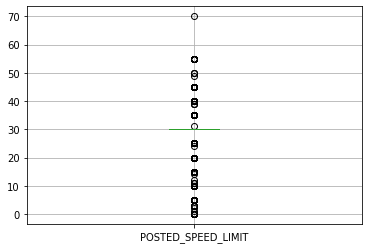

```python
#create a boxplot for POSTED_SPEED_LIMIT to review any outliers
crashes_2020_reviews.boxplot(column=['POSTED_SPEED_LIMIT'])
#There is no unexpected data, so no deletion on POSTED_SPEED_LIMIT
```

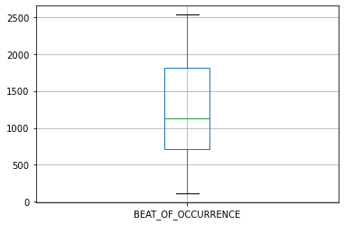

```python
#create a boxplot for BEAT_OF_OCCURRENCE to review any outliers
crashes_2020_reviews.boxplot(column=['BEAT_OF_OCCURRENCE'])
#There is no unexpected data, so no deletion on BEAT_OF_OCCURRENCE
```

```python
#Save the cleaned Crashes 2020 data to Crashes_Feb-Apr_2020_Clean.csv
crashes_2020_reviews.to_csv('Crashes_Feb-Apr_2020_Clean.csv',index=False)
```

## Answer for Step 10

We have two data sources for this project.

**STOP HERE for your EDA Phase 1 assignment. Submit your *cleaned* data file along with the completed notebook up to this point for grading.**

# EDA Phase 2

All of your work for the EDA Phase 2 assignment will begin below here. Refer to the detailed instructions and expectations for this assignment in Canvas.

# Searching for large changes in crash behaviours

We have cleaned up our data and removed many of the unnecessary information. I want to finish setup up some more data visualization of the comparison between 2020 and 2019 in a few categories. Something That came up during brainstorming is that maybe police ticketing of crashes is down because of less police involvement not necessarily fewer crashes. this is something that I will need to dig into to discover more. I want to first start looking at the primary causes of these crashes to help see if there are any clear differences.

## Comparing "Primary Causes of Crash of 2019 vs 2020"

```python
##
prim_cause_2020 = crashes_2020_reviews.PRIM_CONTRIBUTORY_CAUSE.value_counts()
prim_cause_2019 =crashes_2019_reviews.PRIM_CONTRIBUTORY_CAUSE.value_counts()


##Create a new data frame that to compare the crash counts by primary causes and then compare each year
prim_cause_combined_no_pecentage = pd.DataFrame({'2019':prim_cause_2019,'2020':prim_cause_2020})
prim_cause_combined_no_pecentage = prim_cause_combined_no_pecentage.fillna(0)
prim_cause_combined_no_pecentage['2019'] = prim_cause_combined_no_pecentage['2019'].astype(int)
prim_cause_combined_no_pecentage['2020'] = prim_cause_combined_no_pecentage['2020'].astype(int)
prim_cause_combined_no_pecentage
```

|  | 2019 | 2020 |
| --- | --- | --- |
| ANIMAL | 30 | 18 |
| BICYCLE ADVANCING LEGALLY ON RED LIGHT | 5 | 0 |
| CELL PHONE USE OTHER THAN TEXTING | 42 | 31 |
| DISREGARDING OTHER TRAFFIC SIGNS | 50 | 47 |
| DISREGARDING ROAD MARKINGS | 40 | 21 |
| DISREGARDING STOP SIGN | 334 | 233 |
| DISREGARDING TRAFFIC SIGNALS | 472 | 464 |
| DISREGARDING YIELD SIGN | 8 | 13 |
| DISTRACTION - FROM INSIDE VEHICLE | 173 | 155 |
| DISTRACTION - FROM OUTSIDE VEHICLE | 127 | 85 |
| DISTRACTION - OTHER ELECTRONIC DEVICE (NAVIGATION DEVICE, DVD PLAYER, ETC.) | 10 | 12 |
| DRIVING ON WRONG SIDE/WRONG WAY | 130 | 115 |
| DRIVING SKILLS/KNOWLEDGE/EXPERIENCE | 842 | 634 |
| EQUIPMENT - VEHICLE CONDITION | 150 | 172 |
| EVASIVE ACTION DUE TO ANIMAL, OBJECT, NONMOTORIST | 46 | 38 |
| EXCEEDING AUTHORIZED SPEED LIMIT | 169 | 0 |
| EXCEEDING SAFE SPEED FOR CONDITIONS | 136 | 0 |
| FAILING TO REDUCE SPEED TO AVOID CRASH | 1172 | 1133 |
| FAILING TO YIELD RIGHT-OF-WAY | 3104 | 2307 |
| FOLLOWING TOO CLOSELY | 2789 | 1858 |
| HAD BEEN DRINKING (USE WHEN ARREST IS NOT MADE) | 27 | 27 |
| IMPROPER BACKING | 1264 | 819 |
| IMPROPER LANE USAGE | 1056 | 734 |
| IMPROPER OVERTAKING/PASSING | 1324 | 859 |
| IMPROPER TURNING/NO SIGNAL | 1004 | 588 |
| MOTORCYCLE ADVANCING LEGALLY ON RED LIGHT | 1 | 0 |
| NOT APPLICABLE | 1779 | 1027 |
| OBSTRUCTED CROSSWALKS | 0 | 1 |
| OPERATING VEHICLE IN ERRATIC, RECKLESS, CARELESS, NEGLIGENT OR AGGRESSIVE MANNER | 339 | 284 |
| PASSING STOPPED SCHOOL BUS | 7 | 4 |
| PHYSICAL CONDITION OF DRIVER | 185 | 147 |
| RELATED TO BUS STOP | 6 | 16 |
| ROAD CONSTRUCTION/MAINTENANCE | 94 | 19 |
| ROAD ENGINEERING/SURFACE/MARKING DEFECTS | 183 | 33 |
| TEXTING | 10 | 10 |
| TURNING RIGHT ON RED | 14 | 17 |
| UNABLE TO DETERMINE | 9728 | 7518 |
| UNDER THE INFLUENCE OF ALCOHOL/DRUGS (USE WHEN ARREST IS EFFECTED) | 173 | 161 |
| VISION OBSCURED (SIGNS, TREE LIMBS, BUILDINGS, ETC.) | 185 | 104 |
| WEATHER | 535 | 356 |

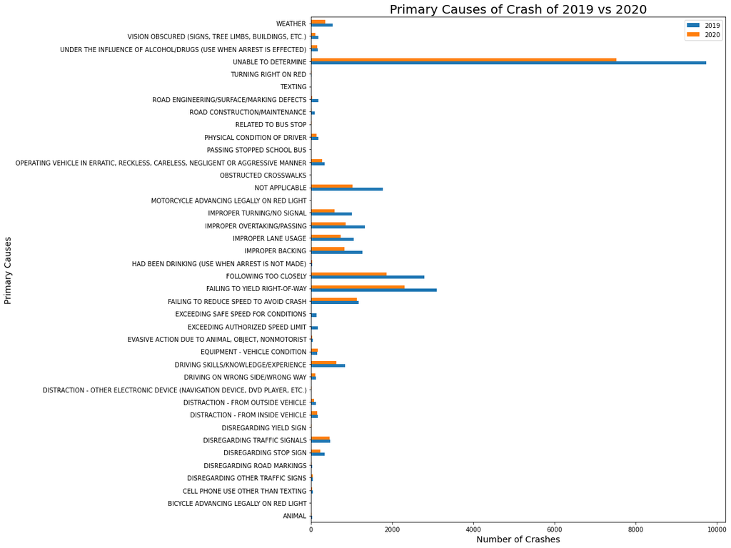

```python
#Graphing results
ax = prim_cause_combined_no_pecentage.plot.barh(title='Primary Causes of Crash of 2019 vs 2020',stacked=False, figsize=(12,15))
ax.set_xlabel("Number of Crashes", fontsize=14)
ax.set_ylabel("Primary Causes", fontsize=14)
ax.title.set_size(20)
```

> There is clearly alot of "Unable to determine" but my first thought is that this graph doesnt tell me much because 2019 had about 7k more crashes. We will need to take a different approach.

## Converting the chart to comparing percentage

After looking at the data we so far can not make any clear indication in driving behaviour when comparing 2019 and 2020. We also need keep in mind that 2019 had total more crashes that were report/documented.

We may need to look at this differently. I want to now look at the percentage of the each primary cause against all crashes from their respective time frame.

```python
## Replacing the NaN as 0 since it means they didnt get any reports of that type of cause for that period.
prim_cause_combined = pd.DataFrame()
prim_cause_combined['2019'] = prim_cause_combined_no_pecentage['2019'].fillna(0)
prim_cause_combined['2020'] = prim_cause_combined_no_pecentage['2020'].fillna(0)

# Adding new columns that represents the percentages of each section
prim_cause_combined["2019 Percentage"] = prim_cause_combined['2019']/prim_cause_combined['2019'].sum()
prim_cause_combined["2020 Percentage"] = prim_cause_combined['2020']/prim_cause_combined['2020'].sum()

## And any year percentages that results in 0 as well
prim_cause_combined['2019 Percentage'] = prim_cause_combined['2019 Percentage'].fillna(0)
prim_cause_combined['2020 Percentage'] = prim_cause_combined['2020 Percentage'].fillna(0)

##Add a difference column to see if there is an impact
prim_cause_combined["Percent Change"]= prim_cause_combined['2020 Percentage']-prim_cause_combined['2019 Percentage']

##Sorting to make it easier to see the greatest changes.
prim_cause_combined.sort_values(by=['Percent Change'], ascending=False)
```

|  | 2019 | 2020 | 2019 Percentage | 2020 Percentage | Percent Change |
| --- | --- | --- | --- | --- | --- |
| UNABLE TO DETERMINE | 9728 | 7518 | 0.350647 | 0.374776 | 0.024129 |
| FAILING TO REDUCE SPEED TO AVOID CRASH | 1172 | 1133 | 0.042245 | 0.056481 | 0.014236 |
| DISREGARDING TRAFFIC SIGNALS | 472 | 464 | 0.017013 | 0.023131 | 0.006117 |
| EQUIPMENT - VEHICLE CONDITION | 150 | 172 | 0.005407 | 0.008574 | 0.003168 |
| FAILING TO YIELD RIGHT-OF-WAY | 3104 | 2307 | 0.111884 | 0.115005 | 0.003121 |
| OPERATING VEHICLE IN ERRATIC, RECKLESS, CARELESS, NEGLIGENT OR AGGRESSIVE MANNER | 339 | 284 | 0.012219 | 0.014158 | 0.001938 |
| UNDER THE INFLUENCE OF ALCOHOL/DRUGS (USE WHEN ARREST IS EFFECTED) | 173 | 161 | 0.006236 | 0.008026 | 0.001790 |
| DISTRACTION - FROM INSIDE VEHICLE | 173 | 155 | 0.006236 | 0.007727 | 0.001491 |
| DRIVING SKILLS/KNOWLEDGE/EXPERIENCE | 842 | 634 | 0.030350 | 0.031605 | 0.001255 |
| DRIVING ON WRONG SIDE/WRONG WAY | 130 | 115 | 0.004686 | 0.005733 | 0.001047 |
| PHYSICAL CONDITION OF DRIVER | 185 | 147 | 0.006668 | 0.007328 | 0.000660 |
| RELATED TO BUS STOP | 6 | 16 | 0.000216 | 0.000798 | 0.000581 |
| DISREGARDING OTHER TRAFFIC SIGNS | 50 | 47 | 0.001802 | 0.002343 | 0.000541 |
| HAD BEEN DRINKING (USE WHEN ARREST IS NOT MADE) | 27 | 27 | 0.000973 | 0.001346 | 0.000373 |
| DISREGARDING YIELD SIGN | 8 | 13 | 0.000288 | 0.000648 | 0.000360 |
| TURNING RIGHT ON RED | 14 | 17 | 0.000505 | 0.000847 | 0.000343 |
| DISTRACTION - OTHER ELECTRONIC DEVICE (NAVIGATION DEVICE, DVD PLAYER, ETC.) | 10 | 12 | 0.000360 | 0.000598 | 0.000238 |
| EVASIVE ACTION DUE TO ANIMAL, OBJECT, NONMOTORIST | 46 | 38 | 0.001658 | 0.001894 | 0.000236 |
| TEXTING | 10 | 10 | 0.000360 | 0.000499 | 0.000138 |
| OBSTRUCTED CROSSWALKS | 0 | 1 | 0.000000 | 0.000050 | 0.000050 |
| CELL PHONE USE OTHER THAN TEXTING | 42 | 31 | 0.001514 | 0.001545 | 0.000031 |
| MOTORCYCLE ADVANCING LEGALLY ON RED LIGHT | 1 | 0 | 0.000036 | 0.000000 | -0.000036 |
| PASSING STOPPED SCHOOL BUS | 7 | 4 | 0.000252 | 0.000199 | -0.000053 |
| BICYCLE ADVANCING LEGALLY ON RED LIGHT | 5 | 0 | 0.000180 | 0.000000 | -0.000180 |
| ANIMAL | 30 | 18 | 0.001081 | 0.000897 | -0.000184 |
| DISTRACTION - FROM OUTSIDE VEHICLE | 127 | 85 | 0.004578 | 0.004237 | -0.000340 |
| DISREGARDING ROAD MARKINGS | 40 | 21 | 0.001442 | 0.001047 | -0.000395 |
| DISREGARDING STOP SIGN | 334 | 233 | 0.012039 | 0.011615 | -0.000424 |
| IMPROPER LANE USAGE | 1056 | 734 | 0.038064 | 0.036590 | -0.001473 |
| VISION OBSCURED (SIGNS, TREE LIMBS, BUILDINGS, ETC.) | 185 | 104 | 0.006668 | 0.005184 | -0.001484 |
| WEATHER | 535 | 356 | 0.019284 | 0.017747 | -0.001537 |
| ROAD CONSTRUCTION/MAINTENANCE | 94 | 19 | 0.003388 | 0.000947 | -0.002441 |
| IMPROPER BACKING | 1264 | 819 | 0.045561 | 0.040828 | -0.004734 |
| EXCEEDING SAFE SPEED FOR CONDITIONS | 136 | 0 | 0.004902 | 0.000000 | -0.004902 |
| IMPROPER OVERTAKING/PASSING | 1324 | 859 | 0.047724 | 0.042822 | -0.004902 |
| ROAD ENGINEERING/SURFACE/MARKING DEFECTS | 183 | 33 | 0.006596 | 0.001645 | -0.004951 |
| EXCEEDING AUTHORIZED SPEED LIMIT | 169 | 0 | 0.006092 | 0.000000 | -0.006092 |
| IMPROPER TURNING/NO SIGNAL | 1004 | 588 | 0.036189 | 0.029312 | -0.006877 |
| FOLLOWING TOO CLOSELY | 2789 | 1858 | 0.100530 | 0.092622 | -0.007908 |
| NOT APPLICABLE | 1779 | 1027 | 0.064124 | 0.051196 | -0.012928 |

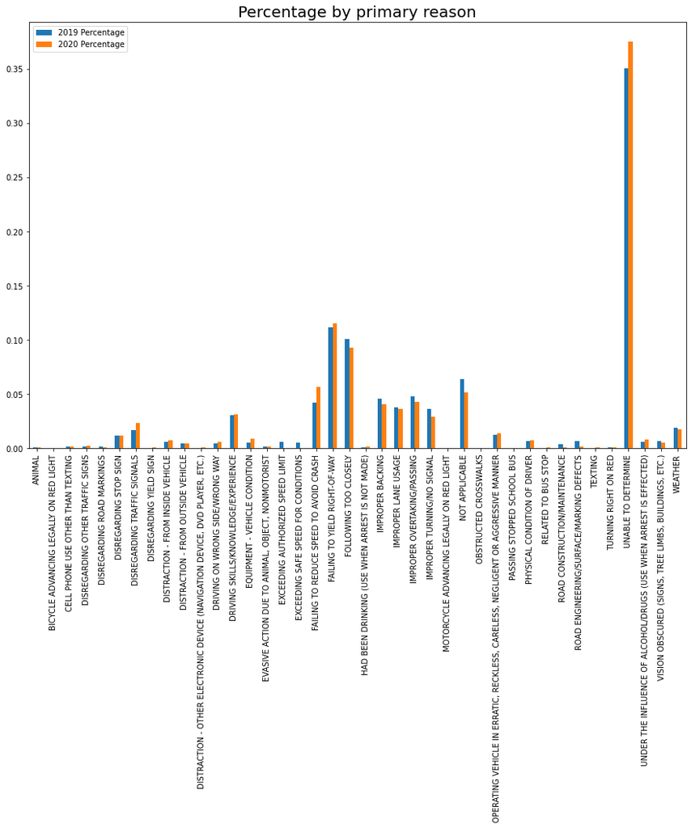

```python
ax2 = prim_cause_combined.plot(title="Percentage by primary reason", y=["2019 Percentage", "2020 Percentage"], kind="bar", figsize=(15,10))
ax2.title.set_size(20)
```

> That looks better a little more cleaner now that we are comparing against the averages of that time frame. We can see reasons like "failed to yield right of way" has gone up and if solely depended on the previous chart we would have not gotten the full picture.

## Comparing "Lighting crashes of 2019 vs 2020"

Lighting I feel is a good indication of time of day. what I mean by this is that people tend to drive a little more reckless during darker lighting.

I will complete this quick its mostly the same as previous charts

|  | 2019 Lighting | 2020 Lighting | 2019 Lighting Percentage | 2020 Lighting Percentage |
| --- | --- | --- | --- | --- |
| DAYLIGHT | 18377 | 12764 | 0.662401 | 0.636291 |
| DARKNESS, LIGHTED ROAD | 5727 | 4632 | 0.206430 | 0.230907 |
| DARKNESS | 1399 | 1032 | 0.050427 | 0.051446 |
| UNKNOWN | 922 | 687 | 0.033234 | 0.034247 |
| DUSK | 811 | 572 | 0.029233 | 0.028514 |
| DAWN | 507 | 373 | 0.018275 | 0.018594 |

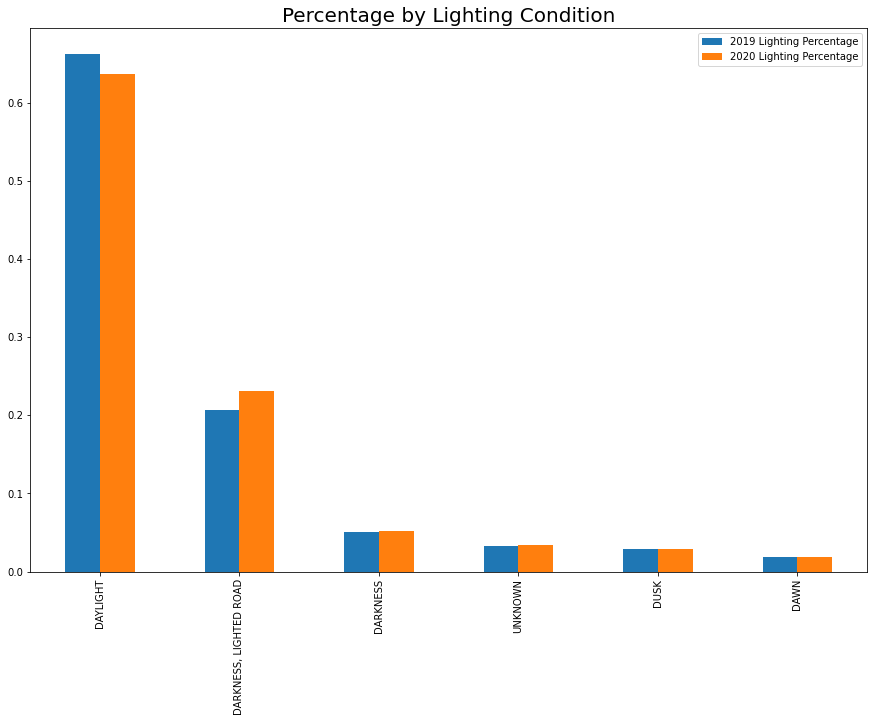

```python
lighting_2020=crashes_2020_reviews.LIGHTING_CONDITION.value_counts()
lighting_2019=crashes_2019_reviews.LIGHTING_CONDITION.value_counts()

lighting_combined = pd.DataFrame({'2019 Lighting':lighting_2019,'2020 Lighting':lighting_2020})


lighting_combined["2019 Lighting Percentage"] = lighting_combined['2019 Lighting']/lighting_combined['2019 Lighting'].sum()
lighting_combined["2020 Lighting Percentage"] = lighting_combined['2020 Lighting']/lighting_combined['2020 Lighting'].sum()

lighting_combined


ax3 = lighting_combined.plot(title="Percentage by Lighting Condition", y=["2019 Lighting Percentage", "2020 Lighting Percentage"], kind="bar", figsize=(15,10))
ax3.title.set_size(20)
```

> Similar to the primary reason for crash chart the data doesn't give any clear indication of change of behavior due to the stay at home manadate. We do a small fluxation of the percentage but nothing that stands out. Next we should look the classified crash types.

# Crash type compparision

I am starting to think that the data quality here may not be the best since we have High Unknown reason. I am making the assumption that officers select that option as the "Go-To" when filling out reports to save time. but crash type cant be misintrepeted as easily

|  | 2019 crash | 2020 crash | 2019 Crash Type Percentage | 2020 Crash Type Percentage |
| --- | --- | --- | --- | --- |
| ANGLE | 3022 | 2174 | 0.108928 | 0.108375 |
| ANIMAL | 17 | 19 | 0.000613 | 0.000947 |
| FIXED OBJECT | 1421 | 1170 | 0.051220 | 0.058325 |
| HEAD ON | 216 | 161 | 0.007786 | 0.008026 |
| OTHER NONCOLLISION | 184 | 42 | 0.006632 | 0.002094 |
| OTHER OBJECT | 362 | 181 | 0.013048 | 0.009023 |
| OVERTURNED | 16 | 7 | 0.000577 | 0.000349 |
| PARKED MOTOR VEHICLE | 6148 | 4942 | 0.221605 | 0.246361 |
| PEDALCYCLIST | 247 | 142 | 0.008903 | 0.007079 |
| PEDESTRIAN | 737 | 542 | 0.026565 | 0.027019 |
| REAR END | 6323 | 4313 | 0.227913 | 0.215005 |
| REAR TO FRONT | 84 | 287 | 0.003028 | 0.014307 |
| REAR TO REAR | 14 | 66 | 0.000505 | 0.003290 |
| REAR TO SIDE | 37 | 158 | 0.001334 | 0.007876 |
| SIDESWIPE OPPOSITE DIRECTION | 472 | 270 | 0.017013 | 0.013460 |
| SIDESWIPE SAME DIRECTION | 4437 | 2788 | 0.159932 | 0.138983 |
| TRAIN | 3 | 5 | 0.000108 | 0.000249 |
| TURNING | 4003 | 2793 | 0.144289 | 0.139232 |

[figure not shown]

```python
crash_type_2020 =crashes_2020_reviews.FIRST_CRASH_TYPE.value_counts()
crash_type_2019 =crashes_2019_reviews.FIRST_CRASH_TYPE.value_counts()

crash_type_combined = pd.DataFrame({'2019 crash':crash_type_2019,'2020 crash':crash_type_2020})


crash_type_combined["2019 Crash Type Percentage"] = crash_type_combined['2019 crash']/crash_type_combined['2019 crash'].sum()
crash_type_combined["2020 Crash Type Percentage"] = crash_type_combined['2020 crash']/crash_type_combined['2020 crash'].sum()

crash_type_combined


ax4 = crash_type_combined.plot(title="Percentage by Lighting Condition", y=["2019 Crash Type Percentage", "2020 Crash Type Percentage"], kind="bar", figsize=(15,10))
ax4.title.set_size(20)
```

> This is starting to look a little better. I was not expecting to see "Parked motor vehicle" to go up, I was expecting to see categories like "Head On, rear end, side-swipe to go up as those seem to more dangerous. we are on the right track but we can't really determine each crash by the type maybe we should gear it towards the total damages cost and see if locations changed. Also crashes like "Rear to front", "Rear to side", and "Rear to Rear" seems to point to crashes where there is 1 active car because I Can't see how 2 cars can backup in each other that many times unless there is 1 driver driving recklessly.

|  | 2019 damage | 2020 damage | 2019 damage Percentage | 2020 damage Percentage |
| --- | --- | --- | --- | --- |
| OVER $1,500 | 16042 | 12168 | 0.578236 | 0.606580 |
| $501 - $1,500 | 8028 | 5561 | 0.289370 | 0.277218 |
| $500 OR LESS | 3673 | 2331 | 0.132394 | 0.116201 |

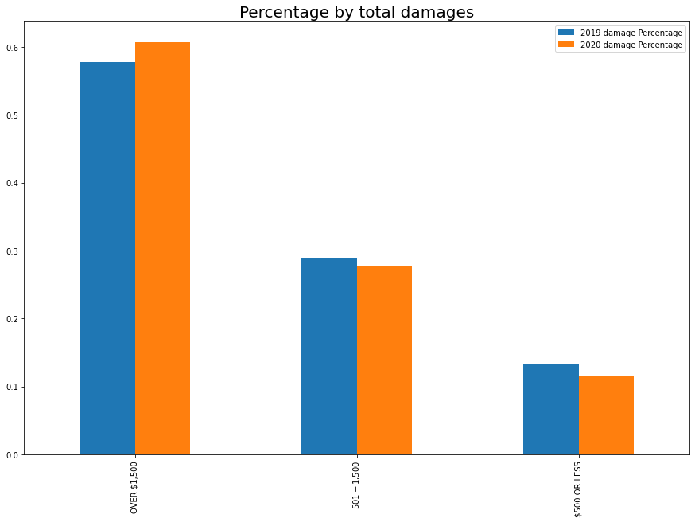

```python
## Creating new data frames to count the costs caused by crash by ranges.
damage_2020 =crashes_2020_reviews.DAMAGE.value_counts()
damage_2019 =crashes_2019_reviews.DAMAGE.value_counts()

## Creating Combined DF to used in comparing
damage_combined = pd.DataFrame({'2019 damage':damage_2019,'2020 damage':damage_2020})

##Adding a percentage column.
damage_combined["2019 damage Percentage"] = damage_combined['2019 damage']/damage_combined['2019 damage'].sum()
damage_combined["2020 damage Percentage"] = damage_combined['2020 damage']/damage_combined['2020 damage'].sum()

## Displaying DF
damage_combined

## Graphing Chart
ax5 = damage_combined.plot(title="Percentage by total damages", y=["2019 damage Percentage", "2020 damage Percentage"], kind="bar", figsize=(15,10),)
ax5.title.set_size(20)
```

> Here we can see that there has been a 3% increase of major damages with "Over 1,500" this is good as we can guess from the crashes the severity has increased because the cost of the damages has gone up. We also can also make the assumption that these increased damages are happening to fixed objects. Things like "Park vehicles because as from the other chart we can see that they had a 2% increase as well as a few other "Non-moving objects". This makes sense because even if the vehicle was speeding or driving recklessly hitting another vehicle would be less likely with fewer drivers on the road. So non-moving object-related crashes have increased or in general, fewer crashes occurred which is both true from our data.

## Traffic Way type

Traffic Way is where the crash happend, like intersections, one-ways highways, etc. I am expecting crashes to more like occur in areas where there is more things to hit like narrow streets, one-ways and non- divided roads.

|  | 2019 traffic way | 2020 traffic way | 2019 Trafficway Percentage | 2020 Trafficway Percentage |
| --- | --- | --- | --- | --- |
| ALLEY | 426 | 360 | 0.015355 | 0.017946 |
| CENTER TURN LANE | 278 | 136 | 0.010021 | 0.006780 |
| DIVIDED - W/MEDIAN (NOT RAISED) | 5026 | 3007 | 0.181163 | 0.149900 |
| DIVIDED - W/MEDIAN BARRIER | 1608 | 1088 | 0.057961 | 0.054237 |
| DRIVEWAY | 91 | 64 | 0.003280 | 0.003190 |
| FIVE POINT, OR MORE | 7 | 39 | 0.000252 | 0.001944 |
| FOUR WAY | 293 | 1551 | 0.010561 | 0.077318 |
| L-INTERSECTION | 1 | 8 | 0.000036 | 0.000399 |
| NOT DIVIDED | 13026 | 8351 | 0.469524 | 0.416301 |
| NOT REPORTED | 2 | 11 | 0.000072 | 0.000548 |
| ONE-WAY | 3681 | 2794 | 0.132682 | 0.139282 |
| OTHER | 844 | 444 | 0.030422 | 0.022134 |
| PARKING LOT | 2031 | 1411 | 0.073208 | 0.070339 |
| RAMP | 81 | 64 | 0.002920 | 0.003190 |
| ROUNDABOUT | 2 | 14 | 0.000072 | 0.000698 |
| T-INTERSECTION | 48 | 365 | 0.001730 | 0.018195 |
| TRAFFIC ROUTE | 9 | 24 | 0.000324 | 0.001196 |
| UNKNOWN | 257 | 193 | 0.009264 | 0.009621 |
| UNKNOWN INTERSECTION TYPE | 27 | 92 | 0.000973 | 0.004586 |
| Y-INTERSECTION | 5 | 44 | 0.000180 | 0.002193 |

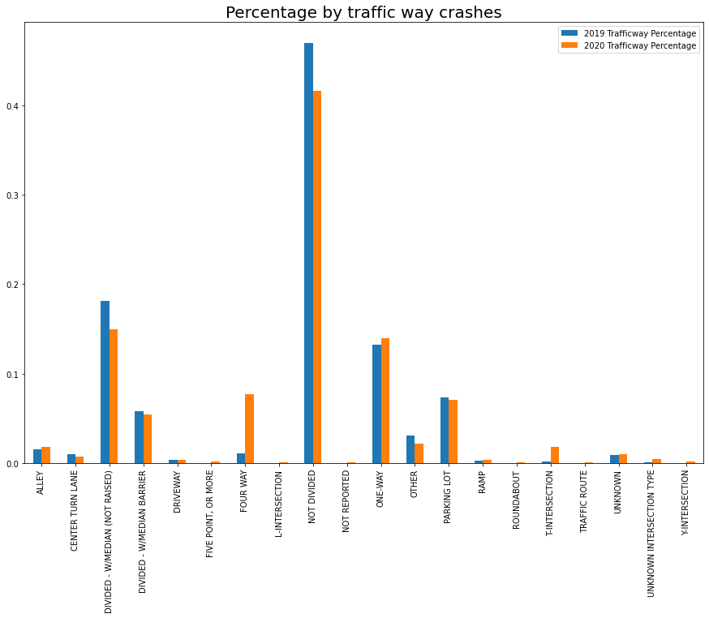

```python
##Create new data frame for each trafficway year
trafficway_2020 =crashes_2020_reviews.TRAFFICWAY_TYPE.value_counts()
trafficway_2019 =crashes_2019_reviews.TRAFFICWAY_TYPE.value_counts()

##Combine them together to be graphed
trafficway_combined = pd.DataFrame({'2019 traffic way':trafficway_2019,'2020 traffic way':trafficway_2020})

## Add precentages to be used in comparrison
trafficway_combined["2019 Trafficway Percentage"] = trafficway_combined['2019 traffic way']/trafficway_combined['2019 traffic way'].sum()
trafficway_combined["2020 Trafficway Percentage"] = trafficway_combined['2020 traffic way']/trafficway_combined['2020 traffic way'].sum()

## Display DF
trafficway_combined

## Graph Df
ax6 = trafficway_combined.plot(title="Percentage by traffic way crashes", y=["2019 Trafficway Percentage", "2020 Trafficway Percentage"], kind="bar", figsize=(15,10),)
ax6.title.set_size(20)
```

## Understanding trafficways

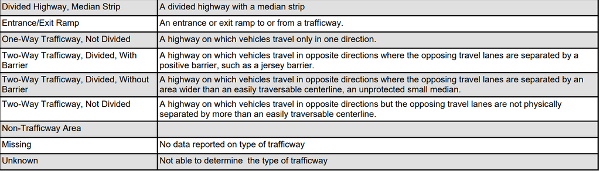

```python
#Import library
from IPython.display import Image

# Load image from local storage
Image(filename = "TrafficWay report.png", width = 600, height = 300)
```

> Above is the breakdown of each trafficway not everything is there but there should be enough info to fill in the gaps. Alley, Four-way, one-way, and T- intersection All have seen increases small or large. This mostly makes sense as one way and alleys are narrow and have a property and are more likely to hit something if driving recklessly. Four-way and T- intersection I can only think that they are either speeding through the intersections and hitting something or another car.

|  | 2019 beats | 2020 beats | 2019 beats Percentage | 2020 beats Percentage |
| --- | --- | --- | --- | --- |
| 01 | 1766 | 1022 | 0.063656 | 0.050947 |
| 02 | 882 | 698 | 0.031792 | 0.034796 |
| 03 | 854 | 778 | 0.030783 | 0.038784 |
| 04 | 1084 | 975 | 0.039073 | 0.048604 |
| 05 | 645 | 556 | 0.023249 | 0.027717 |
| 06 | 1268 | 961 | 0.045705 | 0.047906 |
| 07 | 789 | 701 | 0.028440 | 0.034945 |
| 08 | 2356 | 1789 | 0.084922 | 0.089182 |
| 09 | 1474 | 1077 | 0.053131 | 0.053689 |
| 10 | 1065 | 844 | 0.038388 | 0.042074 |
| 11 | 1162 | 1019 | 0.041884 | 0.050798 |
| 12 | 2056 | 1167 | 0.074109 | 0.058175 |
| 14 | 1051 | 704 | 0.037883 | 0.035095 |
| 15 | 790 | 676 | 0.028476 | 0.033699 |
| 16 | 1833 | 1277 | 0.066071 | 0.063659 |
| 17 | 1187 | 774 | 0.042786 | 0.038584 |
| 18 | 1642 | 988 | 0.059186 | 0.049252 |
| 19 | 1429 | 900 | 0.051508 | 0.044865 |
| 20 | 720 | 448 | 0.025952 | 0.022333 |
| 22 | 894 | 736 | 0.032224 | 0.036690 |
| 24 | 1029 | 638 | 0.037090 | 0.031805 |
| 25 | 1767 | 1332 | 0.063692 | 0.066401 |

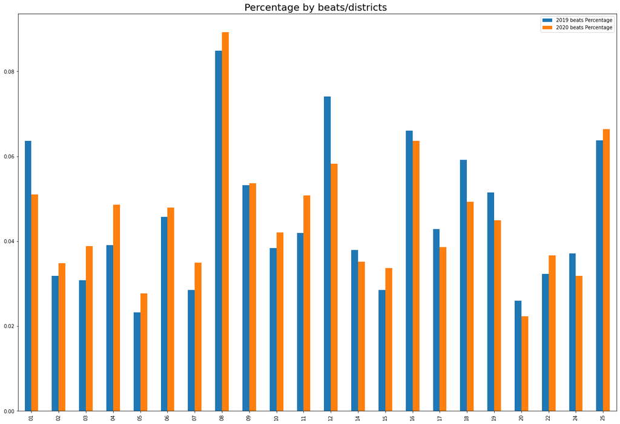

```python
# Creating Temp files so dont overwrite main files
temp_beats_2020 = crashes_2020_reviews
temp_beats_2019 = crashes_2019_reviews

# the beats are 5 digits long so we are appending 0s in front for making beats uniform
temp_beats_2020["BEAT_OF_OCCURRENCE"] = temp_beats_2020["BEAT_OF_OCCURRENCE"].apply(lambda x: '{0:0>5}'.format(x))
temp_beats_2019["BEAT_OF_OCCURRENCE"] = temp_beats_2019["BEAT_OF_OCCURRENCE"].apply(lambda x: '{0:0>5}'.format(x))

#Slicing the beats to be zoning since it will help pinpoint areas of crashes
temp_beats_2020["zone"] = temp_beats_2020["BEAT_OF_OCCURRENCE"].str[1:3]
temp_beats_2019["zone"] = temp_beats_2019["BEAT_OF_OCCURRENCE"].str[1:3]

## Counting by the zone
beats_2020 =temp_beats_2020.zone.value_counts()
beats_2019 =temp_beats_2019.zone.value_counts()

## Combining the beats
beats_combined = pd.DataFrame({'2019 beats':beats_2019,'2020 beats':beats_2020})

## providing percentages of the by beats
beats_combined["2019 beats Percentage"] = beats_combined['2019 beats']/beats_combined['2019 beats'].sum()
beats_combined["2020 beats Percentage"] = beats_combined['2020 beats']/beats_combined['2020 beats'].sum()

## Display DF
beats_combined

##Graph
ax7 = beats_combined.plot(title="Percentage by beats/districts ", y=["2019 beats Percentage", "2020 beats Percentage"], kind="bar", figsize=(22,15))
ax7.title.set_size(20)
```

> There is clearly a skew in crashes towards the lower districts which represents the south side as I will post the graph / infomational sections below.

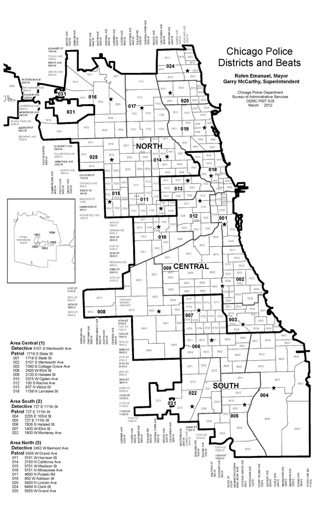

```python
# Load image from local storage
Image(filename = "Beats_No_color1.png", width = 600, height = 300)
```

## Zone count and breakdown

We now know what zones have generally increased or decreases and its still a bit broad to get an understanding where crashes have increased or decreased but, We can quickly allocate this.

2020 crash zones that Increased: 2, 3, 4, 5, 6, 7, 8, 9, 10, 11, 15, 22, 25

```
Central_Zone:2,3,8,9,10       South_Zone:4,5,6,7,22        North_Zone:11,15,25
Central_Count: 5              South_Count:5                North_Count: 3
```

2020 crash zones that Decreased: 1, 12, 14, 16, 17, 18, 19, 20, 24,

```
Central_Zone: 1,12,18                South_Zone:                  North_Zone:14,16,17,19,20,24
Central_Count: 3                     South_Count: 0               North_Count: 6
```

We can see that there has been an increase of 13 beats and decrease of 9 but what is more intresting there all increases of crashes in the south side. While North side has decreased by double of the increase while central remains somewhere inbetween.

I think its safe to assume that crashes that when crashes did occur it was mainly happening in southside>central>northside

## Colorized Map

I have created a map for visualization. the map is not precise nor should it be considered as a heat map since there are no varying levels of increases or decreases. This should further support the hypothesis that the southern side of the city had increased crashes/ reckless driving.

For district 013 we didn't get any crash reports so it was left out.

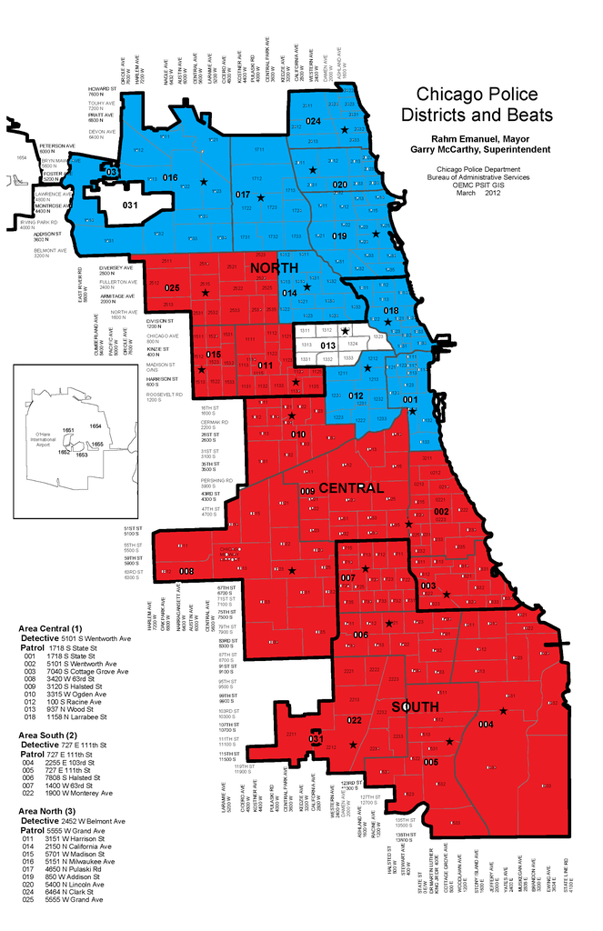

```python
Image(filename = "Beats_color.png", width = 600, height = 300)
```

# Overview

So after reviewing the data, our hypothesis is somewhat correct, Originally we expected increases in crashes in terms of incidents like head-on or rear ends in cities and highways. What we ended up uncovering is that when compared to the previous year there have been increases in crashes where they hit objects, not other moving cars.

Time of day/lighting has not changed much so I don't it played a factor as much.

Trafficways indicate that crashes tend to happen in areas where they would more likely occur in an alleyway, one-ways, and intersection. another major spike of traffic ways was a 4-way intersection and when we look back the primary reason for crashes one of them was " Failing to yield right of way and fail to slow down to avoid crashes."

Location/beats: indicates southside increases in crashes. creating the colorized map we can see that as we move more north we have decreased crashes and central has a mixture of both which would make sense. explaining why southside has more crash I don't believe I can determine.